# PEC

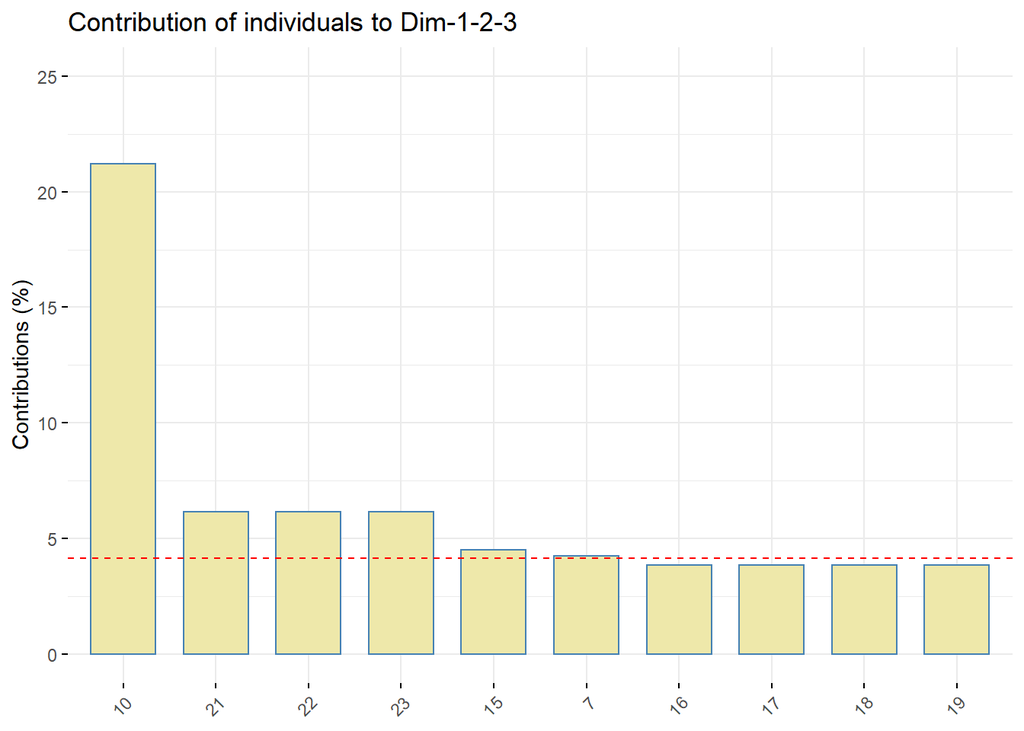

Se agrupan los objetos por grupos similares en elipses de confianza:

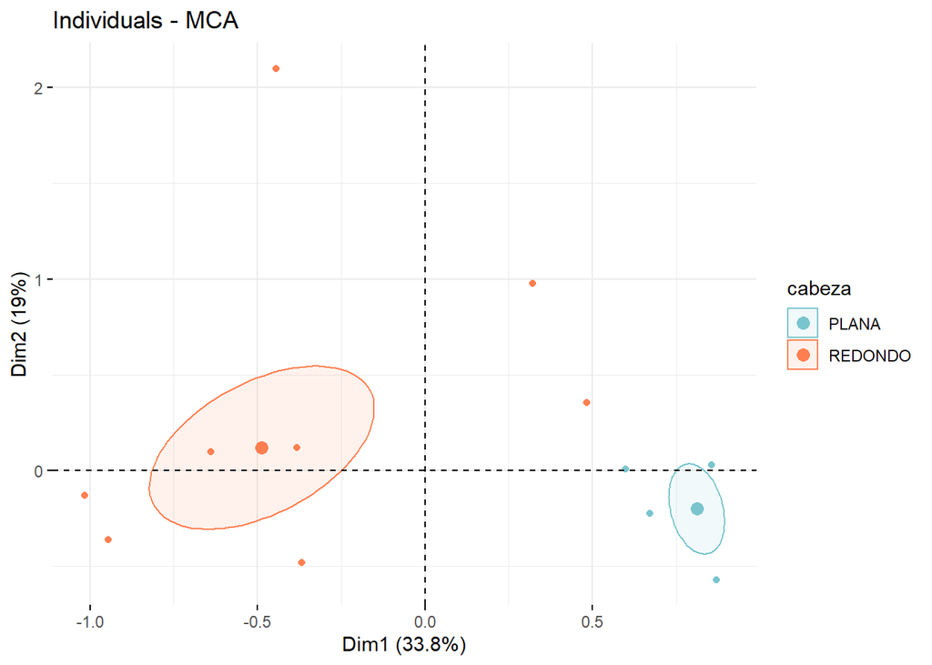

Se realiza el filtrado de los resultados:

Se muestran las variables con mayor calidad de representación:

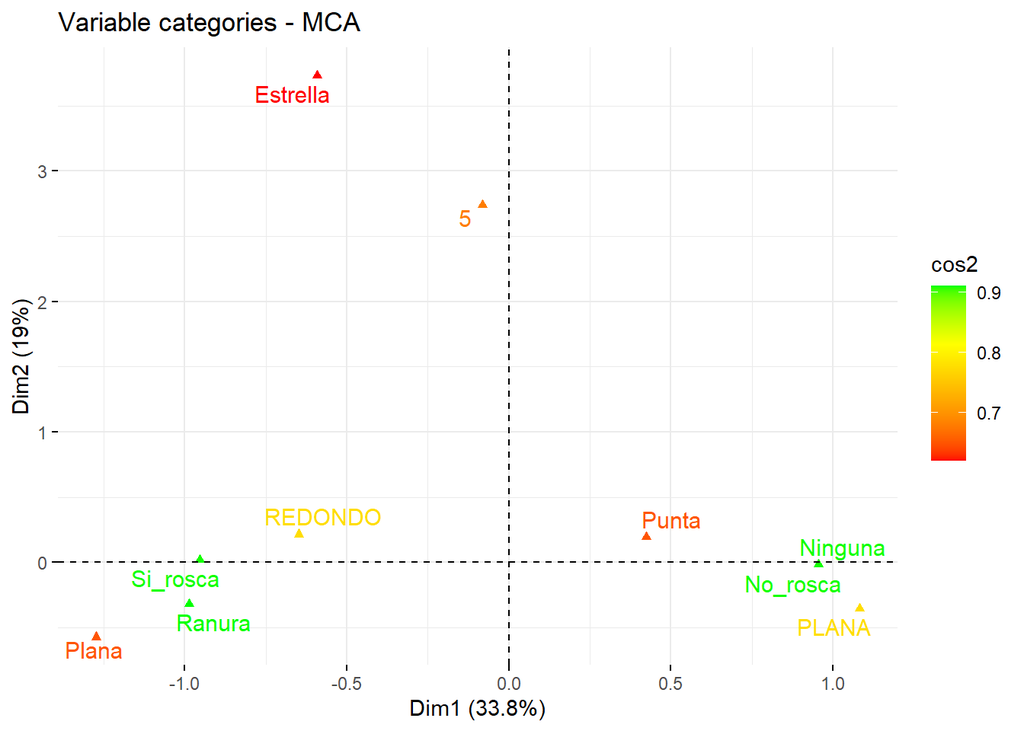

Se muestran los 5 objetos y las 5 variables que más contribuyen a las dimensiones:

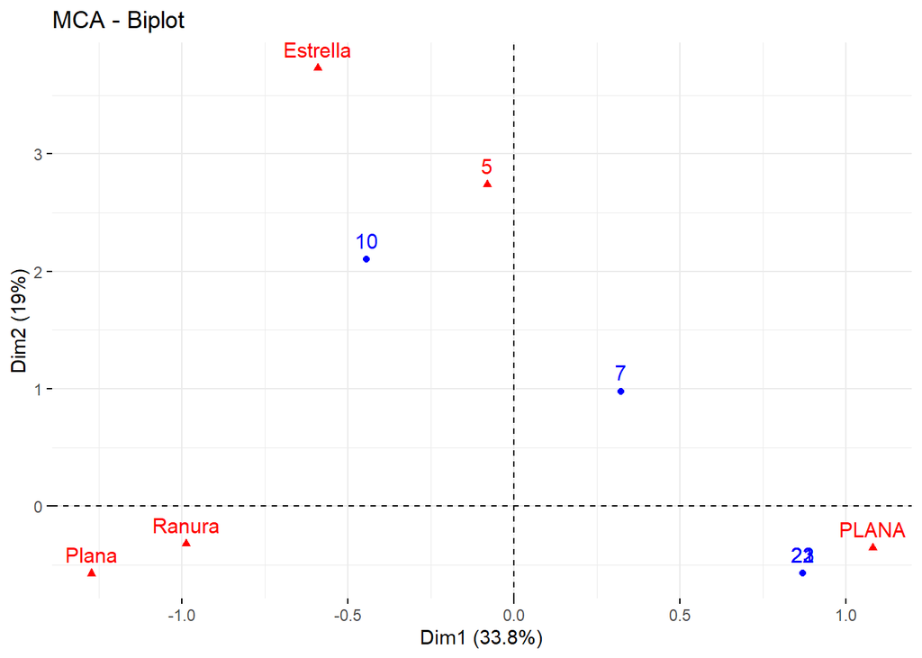

Hay tres grupos de objetos:

- Un grupo de objetos está relacionado positivamente con la dimensión 1 y además estos objetos están relacionados entre ellos, sin apenas relación con la dimensión 2. Estos objetos comparten características similares.
- Hay un segundo grupo que está relacionado negativamente con la dimensión 1 y además están relacionados entre ellos, sin apenas relación con la dimensión 2.Estos objetos comparten características similares.
- El tercer grupo se refiere al único objeto de la muestra con la muesca de estrella, está relacionado negativamente con la dimensión 1 y positivamente con la dimensión 2.

**5. Escalamiento Multidimensional y Análisis Cluster**

**• Con los datos del fichero Datos CCAA.xlsx realice el escalamiento multidimensional que crea más oportuno. Interprete las dimensiones obtenidas.**

Se realiza un escalamiento multidimensional no métrico (se presupone una relación no-lineal entre las proximidades y las distancias de las Comunidades Autónomas). Se muestra el gráfico que resulta tras el escalamiento:

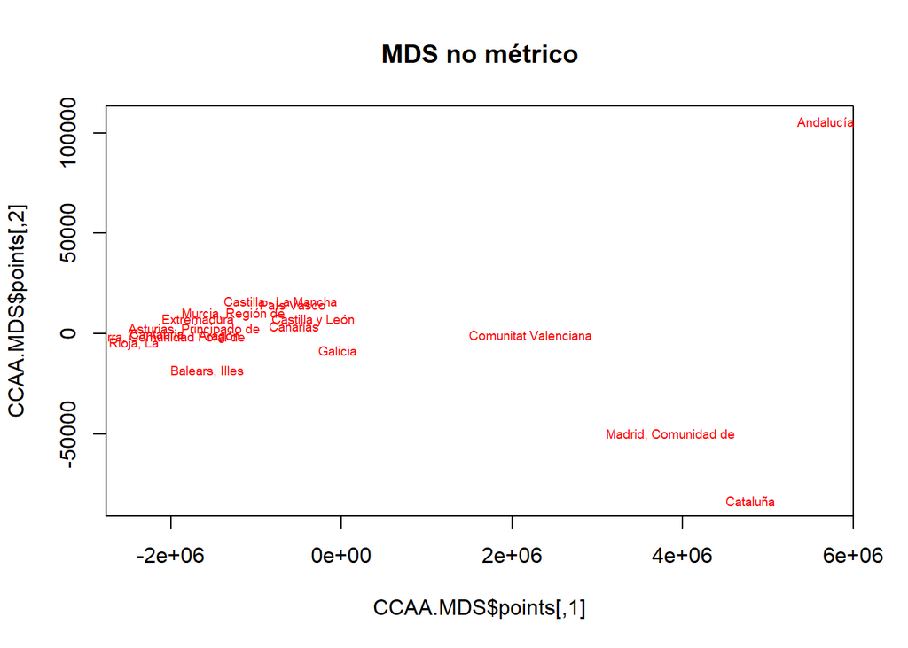

Se muestra el ajuste del escalamiento.

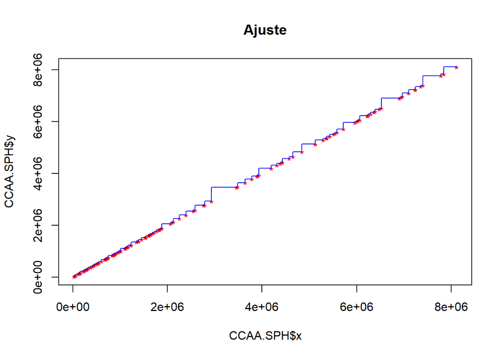

**• Utilizando las coordenadas en las dimensiones obtenidas para cada comunidad autónoma, realice un análisis cluster, seleccione el número de clústeres más adecuado y describa cada grupo en función de las características de las comunidades autónomas incluidas en él.**

Se muestran las coordenadas obtenidas para cada comunidad autónoma:

|  | Dim1 | Dim2 |
| --- | --- | --- |
| Andalucía | 5676710 | 105749.67 |
| Aragón | -1427686 | -1213.29 |
| Asturias, Principado de | -1720606 | 2265.81 |
| Balears, Illes | -1566178 | -18245.79 |
| Canarias | -552546 | 3854.65 |
| Cantabria | -2165319 | 169.07 |
| Castilla y León | -329884 | 6969.58 |
| Castilla - La Mancha | -711919 | 16255.17 |
| Cataluña | 4800447 | -82952.64 |
| Comunitat Valenciana | 2216886 | -337.23 |
| Extremadura | -1677971 | 7534.51 |
| Galicia | -39182 | -8074.35 |
| Madrid, Comunidad de | 3865742 | -50081.98 |
| Murcia, Región de | -1264984 | 10065.54 |
| Navarra, Comunidad Foral de | -2099794 | -1716.71 |
| País Vasco | -569618 | 14703.91 |
| Rioja, La | -2434098 | -4945.92 |

Las coordenadas se cargan en el análisis clúster. A continuación, se muestra el gráfico del análisis clúster:

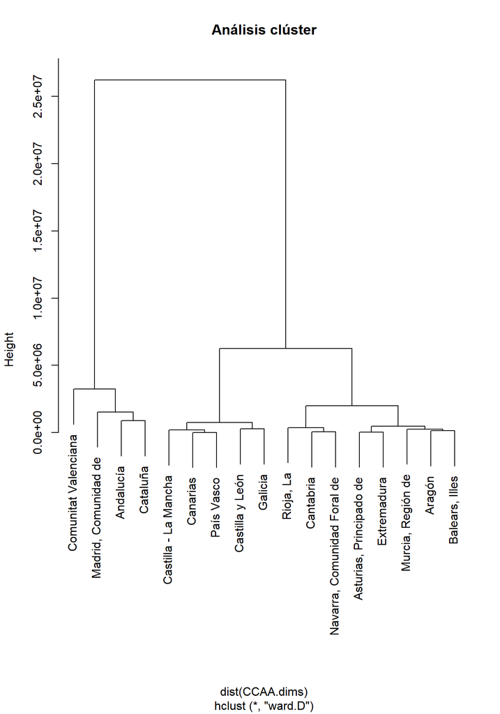

Se muestra el análisis clúster con 6 conglomerados:

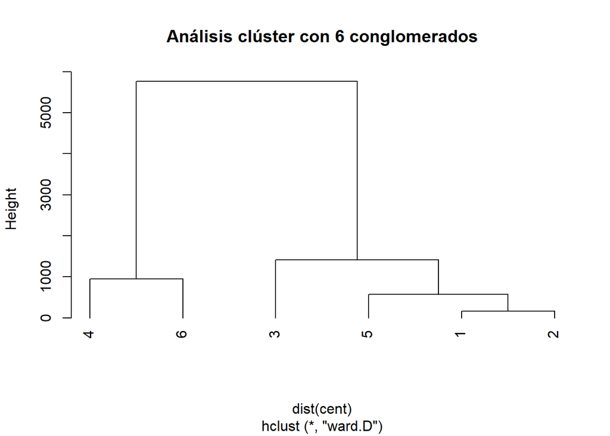

De izquierda a derecha los conglomerados representan:

- El clúster 4 incluye a : Valencia.
- El clúster 6 incluye a : Madrid, Andalucía y Cataluña
- El clúster 3 incluye a : Castilla la Mancha, Canarias, País Vasco, Castilla y León y Galicia
- El clúster 5 incluye a : La Rioja, Cantabria y Navarra.
- El clúster 1 incluye a : Asturias y Extremadura
- El clúster 2 incluye a : Murcia, Aragón y Baleares

**6. Análisis de Correlación Canónica**

**El fichero Datos CCAA2.xlsx contiene información relativa al uso de la economía colaborativa procedente de la Encuesta sobre equipamiento y uso de tecnologías de información y comunicación en los hogares 2018.**

**En concreto, las tres primeras columnas hacen referencia al porcentaje de usuarios de internet que utilizan webs o apps de cara a obtener un servicio de alojamiento, y las tres siguientes hacen referencia al servicio de transporte.**

**• Analice esta información mediante un análisis de correlación canónica y describa y comente los resultados obtenidos.**

En primer lugar se normalizan las variables. A continuación dividimos las variables de la muestra en dos grupos. Cada grupo contiene variables relacionadas entre sí, de modo que se crea un primer grupo de tres variables que se refieren al porcentaje de usuarios de internet que utilizan webs o apps de cara a obtener un servicio de alojamiento, a este primer grupo de variables junto a sus observaciones lo denominamos por “aloj”. Se crea un segundo grupo de tres variables que se refieren al servicio de transporte, este segundo grupo lo denominamos “trans”. Cada grupo de variables es una matriz que será empleada para realizar el análisis de correlación canónica.

Se calculan las matrices de correlaciones y se representan de forma gráfica:

```
## * `` -> ...1
```

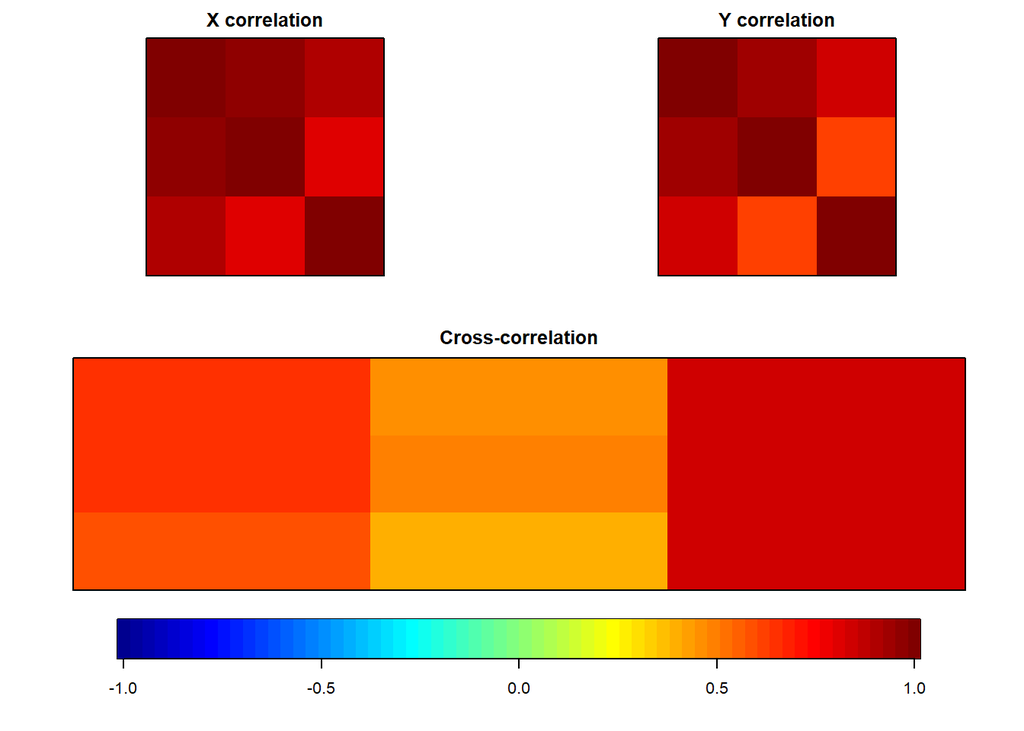

Se observa una alta correlación en las dos matrices de datos “aloj” y “trans”. También hay una alta correlación en algunos puntos de la correlación cruzada entre las dos matrices, esto es, entre “aloj” y “trans”.

Estas altas correlaciones son necesarias para poder continuar con el análisis de correlación canónica.

Se realiza el análisis y se muestra un gráfico con la correlación canónica que tiene cada dimensión:

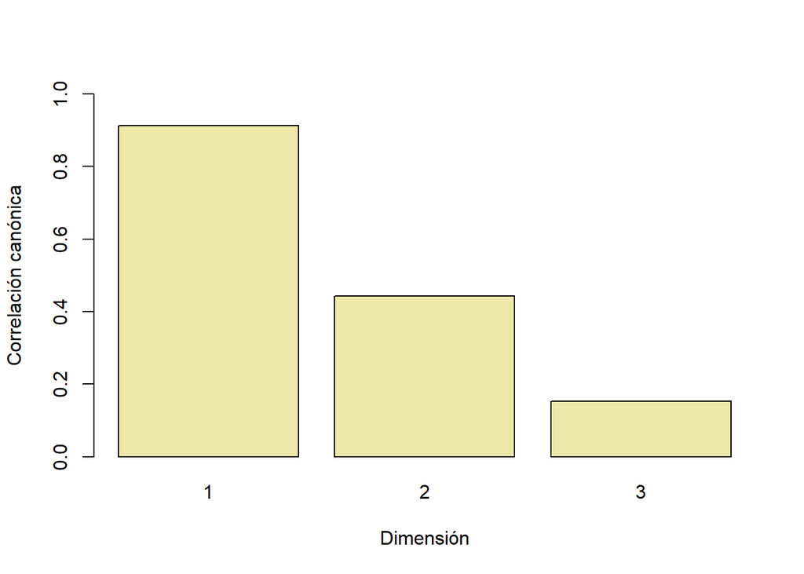

Se obtienen tres dimensiones, una por cada variable que tiene la matriz “aloj”.

Se observa que la primera dimensión tiene un alto grado de correlación canónica, cercano a 1. Esta dimensión representa a las variables de las matrices “aloj” y “trans” que tienen una alta correlación entre ellas. La segunda dimensión tiene un valor de 0.4 y la tercera dimensión no llega a 0.2, por lo que esta última resulta prescindible.

Se estudian los resultados de forma gráfica con el uso de dos dimensiones.

A continuación se muestra la dispersión de las variables con respecto a las dos primeras dimensiones y su relación con las mismas.

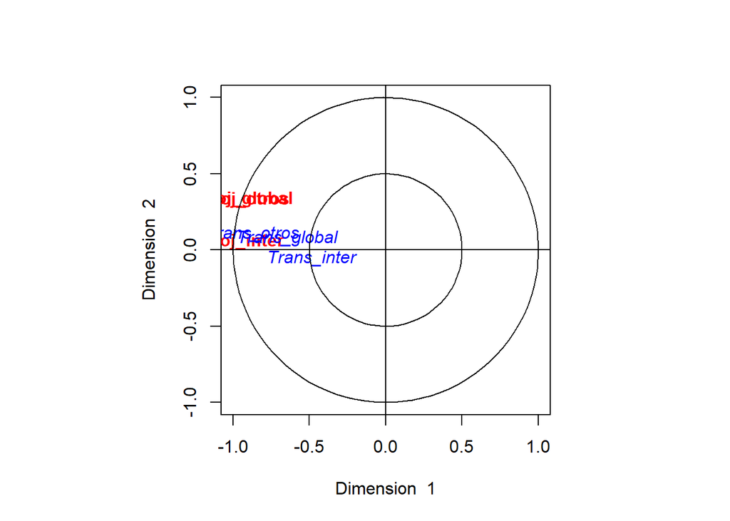

Como todos los puntos se encuentran representados por la dimensión 1 con signo negativo la interpretación es inversa, esto es, a menor valor mayor uso de aplicaciones web de transportes. Y como todos los puntos se encuetran representados por la dimensión 2 con signo positivo, la interpretación es la habitual, a mayor valor mayor uso de las webs de alojamientos.

Ahora se muestra la dispersión de las Comunidades Autónomas con cada una de las dos dimensiones principales y su relación con las mismas.

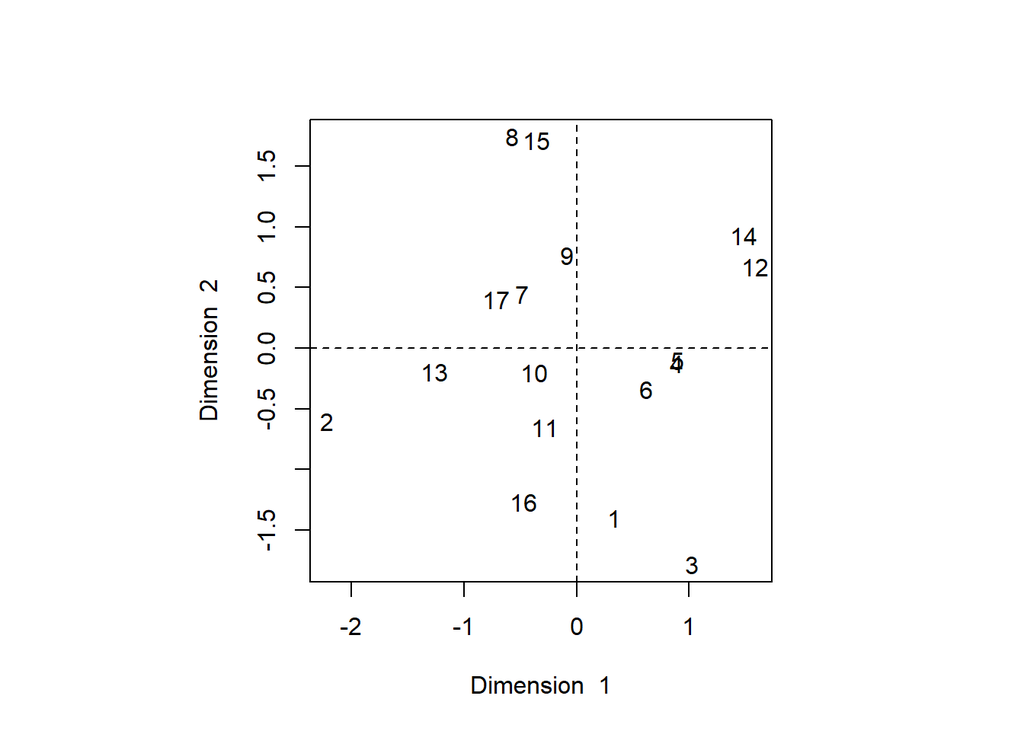

Las Comunidades Autónomas se distribuyen de la siguiente forma:

- Primer cuadrante: relación negativa con la dimensión 1 (interpretación inversa) y relación positiva con la dimensión 2. Comunidades Autónomas: Castilla y León, Castilla-La Mancha, Cataluña, Navarra, Comunidad Foral de y Rioja, La hacen mucho uso de las aplicaciones web de alojamientos y transportes.
- Segundo cuadrante: relación positiva con la dimensión 1 (interpretación inversa) y relación positiva con la dimensión 2. Comunidades Autónomas: Galicia y Murcia, Región de hacen poco uso de las aplicaciones web de transportes y mucho uso de las webs de alojamiento.
- Tercer cuadrante: relación negativa con la dimensión 1 (interpretación inversa) y relación negativa con la dimensión 2. Comunidades Autónomas: Aragón, Comunitat Valenciana, Extremadura, Madrid, Comunidad de y País Vasco hacen mucho uso de las aplicaciones web de transporte y poco uso de las aplicaciones web de alojamientos.
- Cuarto cuadrante: relación positiva con la dimensión 1 (interpretación inversa) y relación negativa con la dimensión 2. Comunidades Autónomas: Andalucía, Asturias, Principado de, Balears, Illes, Canarias y Cantabria hacen poco uso de las aplicaciones web de transporte y de las aplicaciones web de alojamientos.

**7. Machine Learning**

**Se ha llevado a cabo una campaña de marketing por parte de una empresa sobre 9.134 de sus clientes en cuatro estados de Estados Unidos para ofrecerles un determinado producto. Se dispone de información demográfica, social y de otro tipo de datos relacionados con su gestión económica.**

**Las 24 variables contenidas en la base de datos son las siguientes:**

**• Customer (Código de Cliente)**

**• State (Estado)**

**• Customer Lifetime Value (Valor de vida del cliente)**

**• Response (Respuesta)**

**• Coverage (Cobertura)**

**• Education (Nivel de educación)**

**• Effective To Date (Vigente hasta la fecha)**

**• EmploymentStatus (Estatus de Empleo)**

**• Gender (Género)**

**• Income (Ingresos)**

**• Location Code (Código de localización)**

**• Marital Status (Estado civil)**

**• Monthly Premium Auto (Auto Premio Mensual)**

**• Months Since Last Claim (Meses desde la última reclamación)**

**• Months Since Policy Inception (Meses desde el inicio de la poliza)**

**• Number of Open Complaints (Número de quejas abiertas)**

**• Number of Policies (Número de pólizas)**

**• Policy Type (Tipo de póliza)**

**• Policy (Pólizas)**

**• Renew Offer Type (Renovación tipo de oferta)**

**• Sales Channel (Canal de ventas)**

**• Total Claim Amount (Cantidad total de reclamación)**

**• Vehicle Class (Tipo de vehículo)**

**• Vehicle SizesSEE (Tamaño del vehículo)**

**El objetivo general de este ejercicio es aplicar diferentes métodos y algoritmos de clasificación con el objetivo de seleccionar aquel o aquellos métodos que sean óptimos a la hora de predecir la variable Response (valores: Yes, No, es decir si la campaña ha sido un éxito o no). De los siguientes modelos, estime al menos uno de cada tipo:**

**1) Modelo Lineal Generalizado (Regresión Logística, Regresión Probit).** **2) Árboles de decisión. (CHAID, CART, C5, Random Forest).** **3) Redes Neuronales. (Perceptron Multicapa, Función de Base Radial).**

**Utilice el 80% de la muestra para el entrenamiento de los modelos y el restante 20% para test.**

**Compare los resultados obtenidos por los diferentes modelos construidos, y seleccione el que finalmente utilizaría, utilizando como criterio el área bajo la curva ROC.**

Se realiza la división de la muestra en dos submuestras, una con el 80% de los datos que será el conjunto de datos utilizados para entrenar al modelo y un 20% de datos que se utilizará para testear el desempeño del modelo.

Los datos de entrenamiento se configuran en validación cruzada con 5 remuestreos y 3 iteraciones.

> **MODELOS LINEALES GENERALIZADOS**

Se muestra a continuación el resultado de las métricas obtenidas por un modelo GLM de familia logit con los datos de entrenamiento:

| parameter | ROC | Sens | Spec | Accuracy | Kappa | ROCSD | SensSD | SpecSD | AccuracySD | KappaSD |
| --- | --- | --- | --- | --- | --- | --- | --- | --- | --- | --- |
| none | 0.83584 | 0.97736 | 0.22308 | 0.87218 | 0.27289 | 0.01495 | 0.00506 | 0.02907 | 0.00407 | 0.03018 |

Se muestran las variables más importantes según el modelo GLM logit:

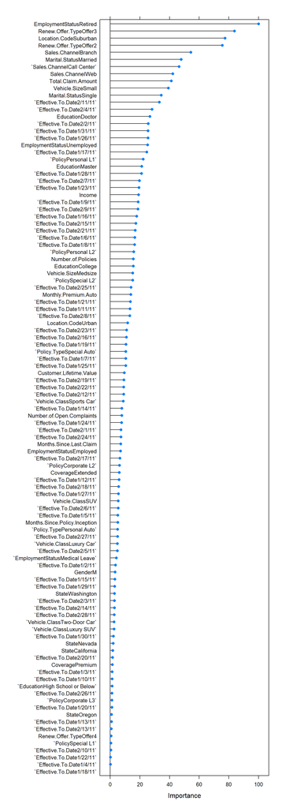

Se calcula el ROC del modelo GLM logit con los datos de test y se presenta la curva ROC:

- El ROC del modelo de validación GLM logit es 0.81

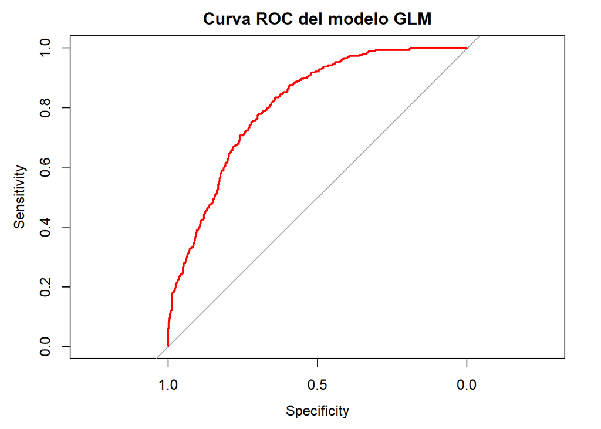

Se muestra a continuación el resultado de las métricas obtenidas por un modelo GLM de familia probit con los datos de entrenamiento:

| parameter | ROC | Sens | Spec | Accuracy | Kappa | ROCSD | SensSD | SpecSD | AccuracySD | KappaSD |
| --- | --- | --- | --- | --- | --- | --- | --- | --- | --- | --- |
| none | 0.83792 | 0.97758 | 0.21885 | 0.87177 | 0.26828 | 0.01141 | 0.00421 | 0.02744 | 0.00336 | 0.02865 |

Se muestran las variables más importantes según el modelo GLM probit:

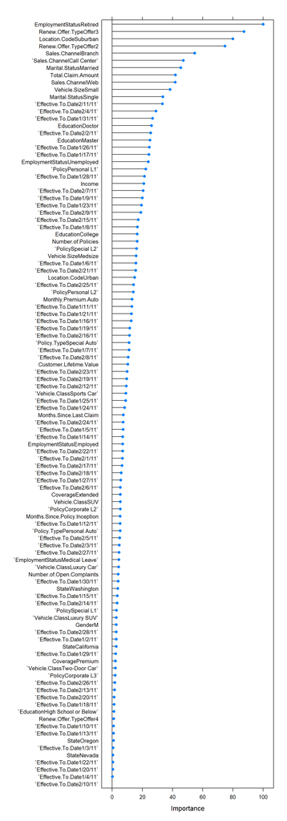

Se calcula el ROC del modelo GLM probit con los datos de test y se presenta la curva ROC:

- El ROC del modelo de validación GLM probit es 0.81

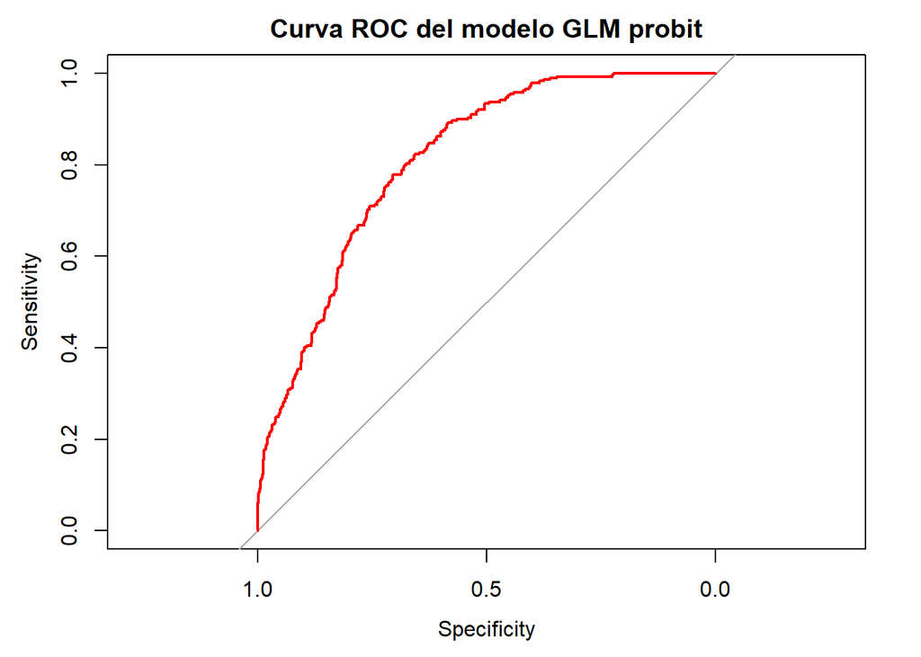

> **MODELOS DE ÁRBOLES DE DECISIÓN**

Se realiza a continuación la estimación de un modelo random forest con el conjunto de datos de entrenamiento y se muestran las métricas obtenidas:

| mtry | ROC | Sens | Spec | Accuracy | Kappa | ROCSD | SensSD | SpecSD | AccuracySD | KappaSD |
| --- | --- | --- | --- | --- | --- | --- | --- | --- | --- | --- |
| 4 | 0.995 | 0.99899 | 0.50344 | 0.92988 | 0.63151 | 0.00434 | 0.00097 | 0.04342 | 0.00647 | 0.04172 |

Se muestran las variables más importantes del modelo RF:

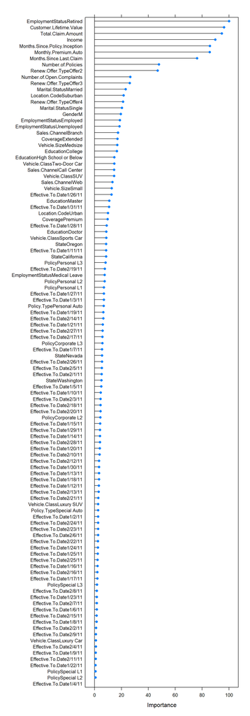

Se calcula el ROC del modelo RF con los datos de test y se presenta la curva ROC:

- El ROC del modelo de validación RF es 1

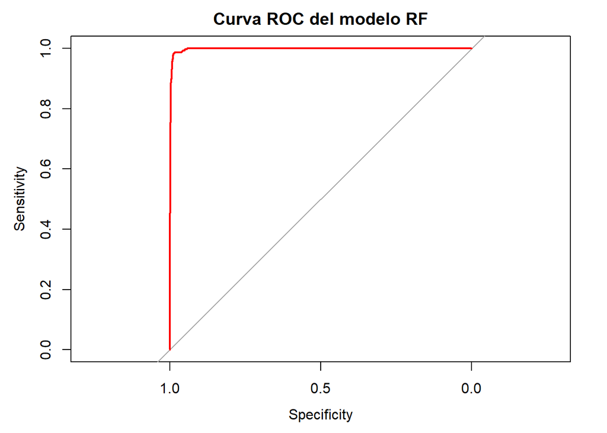

Se prueba, un árbol C5.0, se realiza su estimación usando el conjunto de datos de entrenamiento. Se muestran las métricas obtenidas:

| trials | model | winnow | ROC | Sens | Spec | Accuracy | Kappa | ROCSD | SensSD | SpecSD | AccuracySD | KappaSD |
| --- | --- | --- | --- | --- | --- | --- | --- | --- | --- | --- | --- | --- |
| 10 | rules | TRUE | 0.99515 | 0.99512 | 0.96926 | 0.99152 | 0.96459 | 0.00523 | 0.00267 | 0.02226 | 0.00334 | 0.01415 |

Se muestran las variables más importantes del modelo C5:

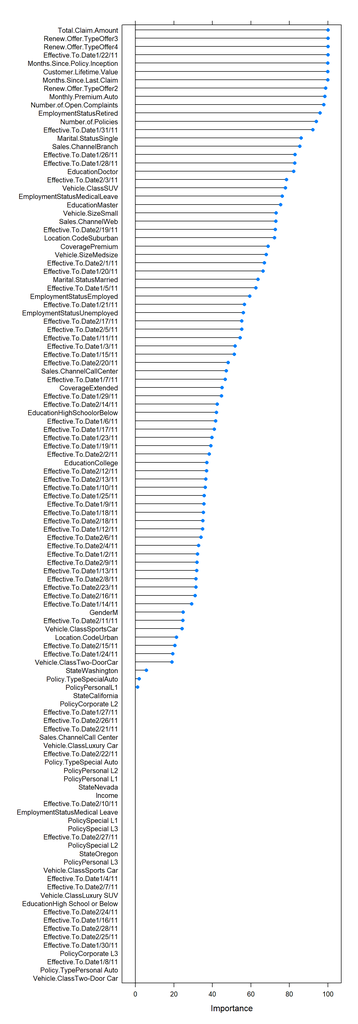

Se calcula el ROC del modelo C5 con los datos de test y se presenta la curva ROC:

- El ROC del modelo de validación C5 es 1

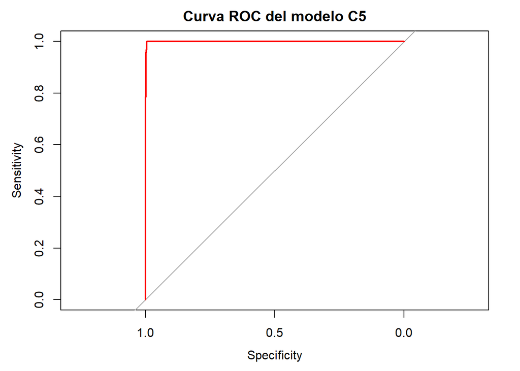

> **MODELOS DE REDES NEURONALES**

Se realiza a continuación la estimación de un modelo Perceptron Multicapa con 20 neuronas usando el conjunto de datos de entrenamiento. Se muestran las métricas obtenidas:

| size | ROC | Sens | Spec | Accuracy | Kappa | ROCSD | SensSD | SpecSD | AccuracySD | KappaSD |
| --- | --- | --- | --- | --- | --- | --- | --- | --- | --- | --- |
| 20 | 0.56286 | 0.99979 | 0 | 0.86036 | -0.00036 | 0.01212 | 0.00082 | 0 | 0.00079 | 0.00139 |

Se muestran las variables más importantes del modelo Perceptron Multicapa:

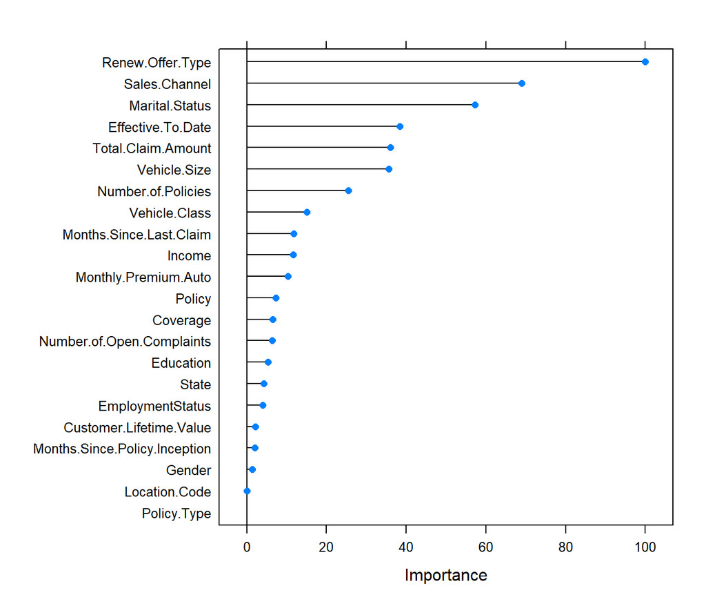

Se calcula el ROC del modelo Perceptron Multicapa con los datos de test y se presenta la curva ROC:

- El ROC del modelo de validación Perceptron Multicapa es 0.56

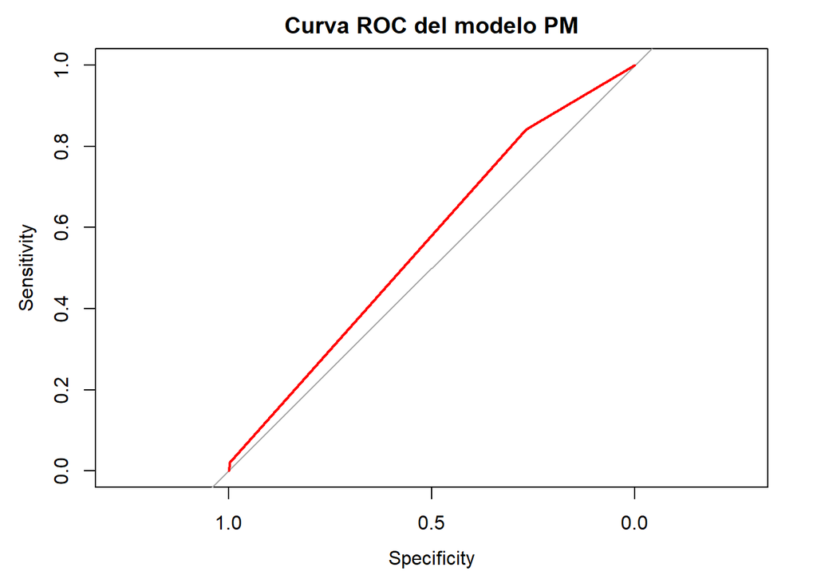

> **COMPARACIÓN DE RESULTADOS**

Se muestra una tabla comparativa con el ROC obtenido por cada modelo utilizando el conjunto de datos de test.

Tabla de resultados

|  | ROC |
| --- | --- |
| GLM logit | 0.8094 |
| GLM probit | 0.8116 |
| Random Forest | 0.9974 |
| C5 | 0.9995 |
| Perceptrón Multicapa | 0.5603 |

Se observa en la tabla que el mejor modelo, y por lo tanto el que utilizaría para el estudio, y según la métrica ROC obtenida con los datos de test, es el árbol C5.0